# Web Mining and Applied NLP (44-620)

## Final Project: Article Summarizer

### Student Name: Brett Neely

Perform the tasks described in the Markdown cells below. When you have completed the assignment make sure your code cells have all been run (and have output beneath them) and ensure you have committed and pushed ALL of your changes to your assignment repository.

You should bring in code from previous assignments to help you answer the questions below.

Every question that requires you to write code will have a code cell underneath it; you may either write your entire solution in that cell or write it in a python file (`.py`), then import and run the appropriate code to answer the question.

```python
from bs4 import BeautifulSoup
import requests
import html5lib
import pickle
import matplotlib.pyplot as plt
import spacy
from spacytextblob.spacytextblob import SpacyTextBlob
from collections import Counter
```

1. Find on the internet an article or blog post about a topic that interests you and you are able to get the text for using the technologies we have applied in the course. Get the html for the article and store it in a file (which you must submit with your project)

```python
URL = 'https://en.wikipedia.org/wiki/Database'
response = requests.get(URL)
article = response.text
```

```python
# Wrtie to a pickle file
with open('article.pkl', 'wb') as file:
    pickle.dump(article, file)
```

2. Read in your article's html source from the file you created in question 1 and do sentiment analysis on the article/post's text (use `.get_text()`). Print the polarity score with an appropriate label. Additionally print the number of sentences in the original article (with an appropriate label)

```python
# Print the article text with Beautiful Soup
soup = BeautifulSoup(article, 'html.parser')
content_div = soup.find('div', {'class': 'mw-parser-output'})
paragraphs = content_div.find_all('p')
article_text = '\n'.join([para.get_text(separator=' ',strip=True) for para in paragraphs if para.get_text(strip=True)])

print(article_text)
```

```
In computing , a database is an organized collection of data or a type of data store based on the use of a database management system ( DBMS ), the software that interacts with end users , applications , and the database itself to capture and analyze the data. The DBMS additionally encompasses the c…
Small databases can be stored on a file system , while large databases are hosted on computer clusters or cloud storage . The design of databases spans formal techniques and practical considerations, including data modeling , efficient data representation and storage, query languages , security and …
Computer scientists may classify database management systems according to the database models that they support. Relational databases became dominant in the 1980s. These model data as rows and columns in a series of tables , and the vast majority use SQL for writing and querying data. In the 2000s, …
Formally, a "database" refers to a set of related data accessed through the use of a "database management system" (DBMS), which is an integrated set of computer software that allows users to interact with one or more databases and provides access to all of the data contained in the database (althoug…
Because of the close relationship between them, the term "database" is often used casually to refer to both a database and the DBMS used to manipulate it.
Outside the world of professional information technology , the term database is often used to refer to any collection of related data (such as a spreadsheet or a card index) as size and usage requirements typically necessitate use of a database management system. [ 1 ]
Existing DBMSs provide various functions that allow management of a database and its data which can be classified into four main functional groups:
Both a database and its DBMS conform to the principles of a particular database model . [ 5 ] "Database system" refers collectively to the database model, database management system, and database. [ 6 ]
Physically, database servers are dedicated computers that hold the actual databases and run only the DBMS and related software. Database servers are usually multiprocessor computers, with generous memory and RAID disk arrays used for stable storage. Hardware database accelerators, connected to one o…
Since DBMSs comprise a significant market , computer and storage vendors often take into account DBMS requirements in their own development plans. [ 7 ]
Databases and DBMSs can be categorized according to the database model(s) that they support (such as relational or XML ), the type(s) of computer they run on (from a server cluster to a mobile phone ), the query language (s) used to access the database (such as SQL or XQuery ), and their internal en…
The sizes, capabilities, and performance of databases and their respective DBMSs have grown in orders of magnitude. These performance increases were enabled by the technology progress in the areas of processors , computer memory , computer storage , and computer networks . The concept of a database …
The two main early navigational data models were the hierarchical model and the CODASYL model ( network model ). These were characterized by the use of pointers (often physical disk addresses) to follow relationships from one record to another.
The relational model , first proposed in 1970 by Edgar F. Codd , departed from this tradition by insisting that applications should search for data by content, rather than by following links. The relational model employs sets of ledger-style tables, each used for a different type of entity . Only in…
Object databases were developed in the 1980s to overcome the inconvenience of object–relational impedance mismatch , which led to the coining of the term "post-relational" and also the development of hybrid object–relational databases .
The next generation of post-relational databases in the late 2000s became known as NoSQL databases, introducing fast key–value stores and document-oriented databases . A competing "next generation" known as NewSQL databases attempted new implementations that retained the relational/SQL model while a…
The introduction of the term database coincided with the availability of direct-access storage (disks and drums) from the mid-1960s onwards. The term represented a contrast with the tape-based systems of the past, allowing shared interactive use rather than daily batch processing . The Oxford Englis…
```

[output cut: 82 more lines]

```python
# Number of sentences
nlp = spacy.load("en_core_web_sm")
nlp.add_pipe("spacytextblob")
doc = nlp(article_text)

number_of_sentences = len(list(doc.sents))
print(f"The article contains {number_of_sentences} number of sentences.")
```

```
The article contains 286 number of sentences.
```

```python
# Polarity Score
polarity_score = round(doc._.blob.polarity, 2)
print(f"The polarity score of this article is {polarity_score}.")
```

```
The polarity score of this article is 0.09.
```

3. Load the article text into a trained `spaCy` pipeline, and determine the 5 most frequent tokens (converted to lower case). Print the common tokens with an appropriate label. Additionally, print the tokens their frequencies (with appropriate labels)

```python
tokens = [token.text.lower() for token in doc if not token.is_stop and not token.is_punct]
token_counts = Counter(tokens)
most_common_tokens = token_counts.most_common(5)

print(f"The five most common tokens are {most_common_tokens}.")
```

```
The five most common tokens are [('database', 178), ('data', 132), ('\n', 98), ('model', 57), ('dbms', 48)].
```

4. Load the article text into a trained `spaCy` pipeline, and determine the 5 most frequent lemmas (converted to lower case). Print the common lemmas with an appropriate label. Additionally, print the lemmas with their frequencies (with appropriate labels).

```python
lemmas = [token.lemma_.lower() for token in doc if not token.is_stop and not token.is_punct]
lemma_counts = Counter(lemmas)
most_common_lemmas = lemma_counts.most_common(5)

print(f"The five most common lemmas are {most_common_lemmas}.")
```

```
The five most common lemmas are [('database', 221), ('\n', 98), ('datum', 97), ('model', 70), ('dbms', 65)].
```

5. Make a list containing the scores (using tokens) of every sentence in the article, and plot a histogram with appropriate titles and axis labels of the scores. From your histogram, what seems to be the most common range of scores (put the answer in a comment after your code)?

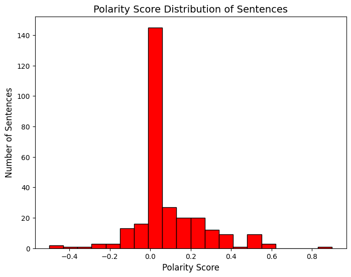

```python
sentence_polarities = [sent._.blob.polarity for sent in doc.sents]
plt.figure(figsize=(8, 6))
plt.hist(sentence_polarities, bins=20, edgecolor='black', color='red')

plt.title("Polarity Score Distribution of Sentences", fontsize=14)
plt.xlabel("Polarity Score", fontsize=12)
plt.ylabel("Number of Sentences", fontsize=12)

plt.show()

# The most common range of scores is 0.0 to 0.1.
```

6. Make a list containing the scores (using lemmas) of every sentence in the article, and plot a histogram with appropriate titles and axis labels of the scores. From your histogram, what seems to be the most common range of scores (put the answer in a comment after your code)?

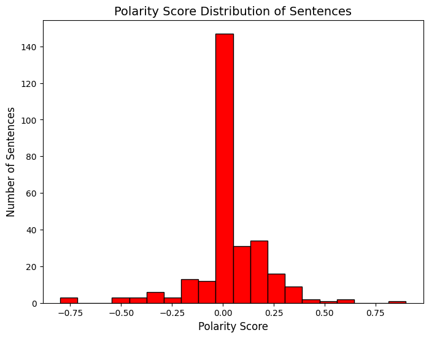

```python
lemma_polarities = []

for sent in doc.sents:
    lemmas = [token.lemma_.lower() for token in sent if not token.is_stop and not token.is_punct]
    lemmas_text = " ".join(lemmas)
    lemmas_doc = nlp(lemmas_text)
    sentence_lemma_polarity = lemmas_doc._.blob.polarity
    lemma_polarities.append(sentence_lemma_polarity)

plt.figure(figsize=(8, 6))
plt.hist(lemma_polarities, bins=20, edgecolor='black', color='red')

plt.title("Polarity Score Distribution of Sentences", fontsize=14)
plt.xlabel("Polarity Score", fontsize=12)
plt.ylabel("Number of Sentences", fontsize=12)

plt.show()

# The most common range of scores is around 0.0.
```